# Corrélation linéaire et Régression Linéaire Multiple à l’aide de R

### 3

On pose : H0 (hypothèse nulle) : Il n’y a pas de corrélation significative entre les valeurs. H1 (hypothèse alternative) : Il y a une corrélation significative entre les valeurs.

```
corrplot 0.92 loaded
```

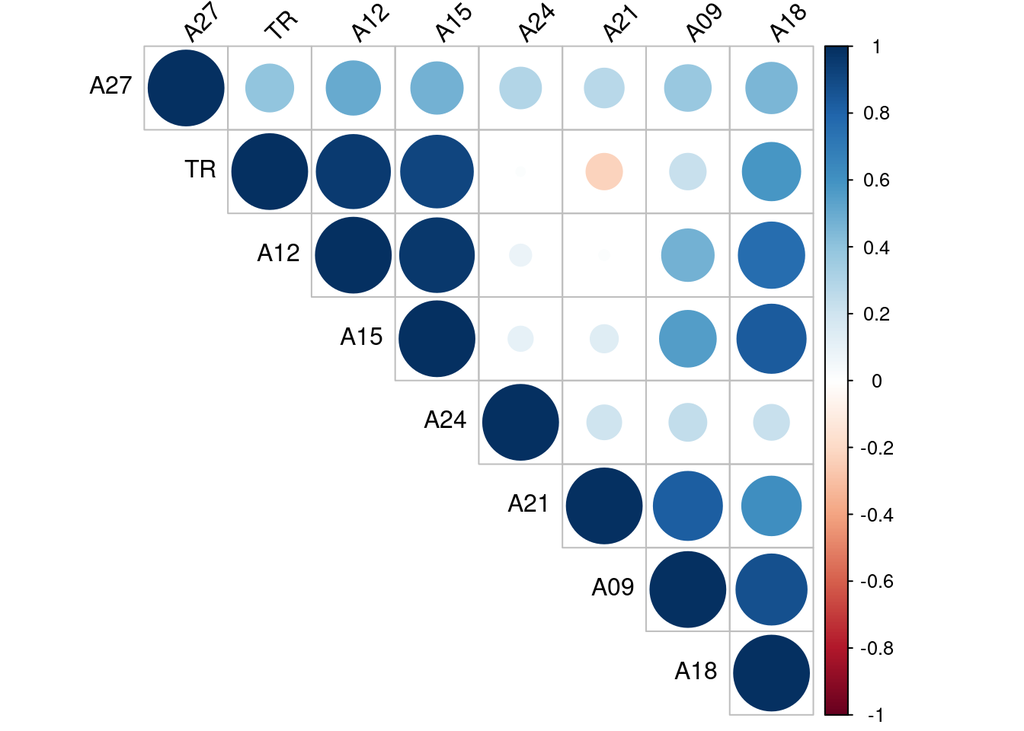

### Régression linéaire multiple avec R : Rédaction et analyse des résultats

### 4

```
Call:
lm(formula = TR ~ ., data = TP1exelnew)

Residuals:
    Min      1Q  Median      3Q     Max
-1.2828 -0.5897 -0.2046  0.7306  1.3645

Coefficients:
            Estimate Std. Error t value Pr(>|t|)
(Intercept)  -0.6184     1.2150  -0.509  0.62453
A09         -16.2561     6.8175  -2.384  0.04424 *
A12          35.1935    10.0644   3.497  0.00812 **
A15          17.0438     7.7553   2.198  0.05920 .
A18          -0.4485    11.4046  -0.039  0.96959
A21          -4.6430    16.6022  -0.280  0.78683
A24           1.7982    11.2612   0.160  0.87709
A27         -13.6170    15.4391  -0.882  0.40351
---
Signif. codes:  0 '***' 0.001 '**' 0.01 '*' 0.05 '.' 0.1 ' ' 1

Residual standard error: 1.112 on 8 degrees of freedom
Multiple R-squared:  0.9903,    Adjusted R-squared:  0.9819
F-statistic: 117.1 on 7 and 8 DF,  p-value: 2.006e-07
```

### 5

On pose: H0 (Hypothèse Nulle) : Tous les coefficients de régression sont égaux à zéro, ce qui signifie que le modèle n’explique pas la variance de la variable dépendante (TR), le modèle n’est donc pas significativement différent d’un modèle sans variables indépendantes.

H1 (Hypothèse Alternative) : Au moins un des coefficients de régression est différent de zéro, ce qui indique que le modèle explique une part significative de la variance de la variable dépendante (TR).

Comme la p-value est < 0.05, alors on peut rejeter l’hypothèse nulle (H0) et conclure que le modèle de régression est globalement significatif.

### 6

En utilisant les sept longueurs d’onde (A09, A12, A15, A18, A21, A24, A27) comme variables indépendantes, le modèle de régression linéaire multiple explique environ 98,18 % de la variation observée dans la variable TR. Cela indique que le modèle est relativement efficace pour prédire les valeurs de TR en fonction de ces longueurs d’onde.